# Investigating the coherency between logical relationships and gene expressions for each connected gene pair in the signaling networks

Mehran Piran

December 12, 2018

piranmehran@gmail.com  
[Researchgate](https://www.researchgate.net/profile/Mehran_Piran)

$~$  
$~$

# Introduction

Study the correlation between the gene expression profiles at both mRNA and protein level is common. Several studies have shown that mRNA and protein expression are poorly correlated. There are some reasons such as miRNA activity on mRNA transcripts or post-translational modifications which cause the variation in amounts of mRNAs and active/inactive Proteins. However, the association between mRNA and protein of housekeeping genes which is not mostly related to signaling processes has been also reported. Now, another major question is the association between mRNA or protein level with the logical relations inside the wiring diagram of the signaling networks. Considering the sign of interactions between components, does the gene expression or protein amount help the signal to be transduced or not? In two simple elements, there are eight possible states (figure 1). Four of these states conform to the direction of the signal transduction, i.e., if the interaction is activation, both of two related components are up-regulated or down-regulated; and if the interaction is inhibitory, the expression of two associated components is inverse (Panel A). The other four possible states are against to signal transduction’s direction (panel B). Analyzing these two different clusters of states in various biological conditions could be an interesting subject for the discussion. Figure 2 is the flowchart which depicts the different steps to reach the data needed to analyze the coherency between the gene pairs in KEGG signaling pathways.

$~$

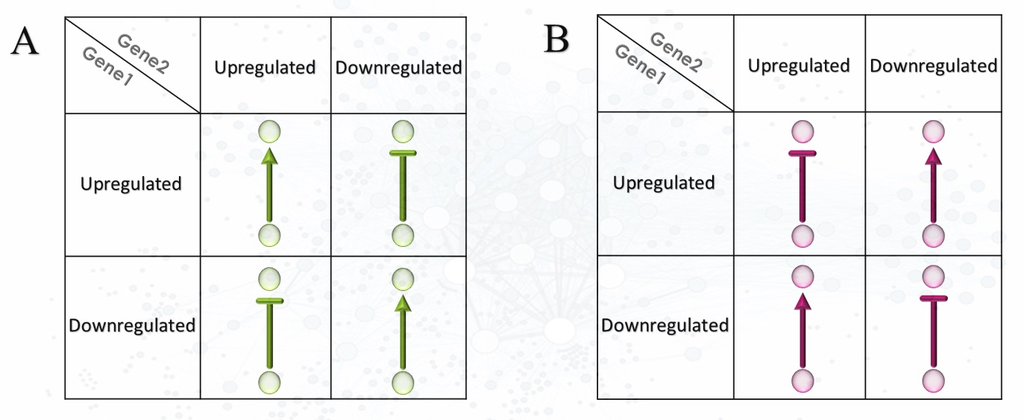

Figure1

$~$  
$~$

# The Procedure

$~$

$~$

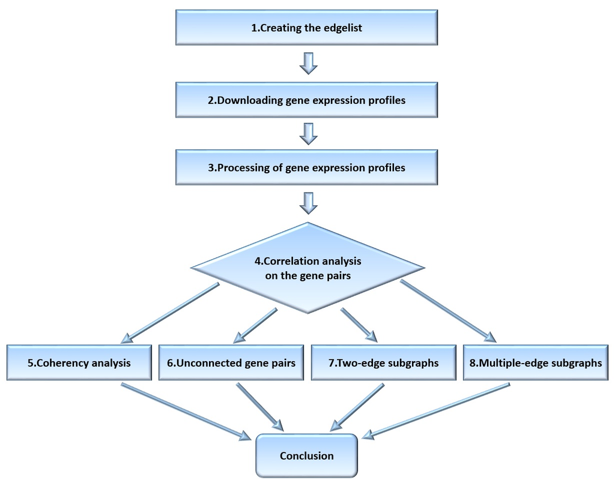

Figure2: Different steps to analyze the coherency between the gene pairs

$~$  
$~$

$~$

# 1.Creating an edgelist from KEGG database

An edgelist was created from all human KEGG pathways using “KEGGgraph” package.

$~$

### 1.1.Downloading KEGG pathways

All the human signaling pathways were downloaded in form of KGML files from KEGG database [KEGG Pathways](http://www.genome.jp/kegg/pathway.html). There were 206 human pathways on July 24th, 2017.

An example of these pathways is: [Ras Signaling Pathway](http://www.genome.jp/kegg-bin/show_pathway?map=hsa04014&show_description=show)  
$~$

### 1.2.Impoting pathways into R in form of graphs

Downloaded pathways were imported into R using the combination of “parseKGML2Graph” and “lapply” functions. The “parseKGML2Graph” is a function which creates a class of graph (graphNEL) from each pathway and is suitable for networks with few edges and high nodes. All 206 graphs were stored in KGMLGraphs object.

```r
library(KEGGgraph)

#Define path
kgfiles<-list.files("F:/Projects/Project Coherency/KEGG GEO/kegg xml",full.names=T)

#Read kgml files
KGMLGraphs=lapply(kgfiles,parseKGML2Graph,genesOnly=F)
length(KGMLGraphs)
```

```
## [1] 206
```

```r
head(KGMLGraphs)
```

```
## [[1]]
## A graphNEL graph with directed edges
## Number of Nodes = 94
## Number of Edges = 247
##
## [[2]]
## A graphNEL graph with directed edges
## Number of Nodes = 115
## Number of Edges = 311
##
## [[3]]
## A graphNEL graph with directed edges
## Number of Nodes = 64
## Number of Edges = 18
##
## [[4]]
## A graphNEL graph with directed edges
## Number of Nodes = 84
## Number of Edges = 79
##
## [[5]]
## A graphNEL graph with directed edges
## Number of Nodes = 93
## Number of Edges = 282
##
## [[6]]
## A graphNEL graph with directed edges
## Number of Nodes = 267
## Number of Edges = 856
```

$~$

### 1.3.Extracting edge information

Edge information is derived from each pathway using “getKEGGedgeData” function, and they are stored in **l** object.

```r
l = lapply(KGMLGraphs,getKEGGedgeData)
length(l)
```

```
## [1] 206
```

$~$

### 1.4. Constructing the edgelists

The following codes construct the edgelists from all 206 signaling pathways and remove the non-informative information. The loop contains two “if” conditions to exclude edges without complete data. Note that, nodes (e.g., hsa: 1950) are genes and Subtype is the relationship between genes, e.g., activation, inhibition and so on. A large list called **listedgelists** is created, and each element contains an edgelist.

```r
# an example of complete informative edge:
l[[1]][[1]]
```

```
##   KEGG Edge (Type: PPrel):
## ------------------------------------------------------------
## [ Entry 1 ID ]: hsa:1950
## [ Entry 2 ID ]: hsa:1956
## [ Subtype ]:
##   [ Subtype name ]: activation
##   [ Subtype value ]: -->
## ------------------------------------------------------------
```

```r
# First exclusive condition: There is no edge between nodes. For example:
KGMLGraphs[[26]]
```

```
## A graphNEL graph with directed edges
## Number of Nodes = 133
## Number of Edges = 0
```

```r
# Second exclusive condition: There is no information about the edge. For example:
l[[10]][[251]]
```

```
##   KEGG Edge (Type: PCrel):
## ------------------------------------------------------------
## [ Entry 1 ID ]: hsa:6543
## [ Entry 2 ID ]: cpd:C01330
## [ Subtype ]:
## ------------------------------------------------------------
```

$~$

```r
a = NULL
class(a)
```

```
## [1] "NULL"
```

```r
b = list()

listedgelists = list()

for(i in 1:length(l)){
  if(is.list(l[[i]]) & length(l[[i]]) == 0){
    listedgelists[[i]] = c(0,0,0)
  } else
  {
  d = matrix(0,length(l[[i]]),3)
  d = as.data.frame(d)
  for(j in 1:length(l[[i]])){
    d[j,1] = l[[i]][[j]]@entry1ID
    d[j,2] = l[[i]][[j]]@entry2ID
    c1 = l[[i]][[j]]@subtype$subtype

    if(class(c1) == class(a)){
      d[j,3] =  "none"
    } else
    {
      d[j,3] = l[[i]][[j]]@subtype$subtype@name
    }

  }

    listedgelists[[i]] = d
  }
}
```

$~$

listedgelists object contains all 206 edgelists.

### 1.5.Merging all edgelists

All the edgelists are attached together and a large edgelist is created.

```r
table = do.call("rbind", listedgelists)
dim(table)
```

```
## [1] 68757     3
```

$~$

Duplicated rows are omitted as below.

```r
table1 = table[!duplicated(table),]
```

$~$

### 1.6. Preprocessing the edgelist

In the following code, “activation” and “inhibition” interactions are separated from each other.

```r
idx1 = which(table1[,3] == "activation")

idx2 = which(table1[,3] == "inhibition")

idx = c(idx1,idx2)

table2 = table1[idx,]

dim(table2)
```

```
## [1] 28870     3
```

$~$

After that, only edges which are KEGG Ids starting with “hsa” are selected.

```r
idx3 = grep("^hsa" , table2[,1])

idx4 = grep("^hsa" , table2[,2])

idx5 = intersect(idx3,idx4)

table3 = table2[idx5,]

dim(table3)
```

```
## [1] 26490     3
```

$~$

```r
sum(!grepl("^hsa" , table3[,1]))
```

```
## [1] 0
```

```r
sum(!grepl("^hsa" , table3[,2]))
```

```
## [1] 0
```

$~$

Next, all the KEGG Ids are changed into gene Ids.

```r
kgid1 = as.character(table3[,1])

kgid2 = as.character(table3[,2])

geneid1 <- translateKEGGID2GeneID(kgid1)

geneid2 <- translateKEGGID2GeneID(kgid2)

any(is.na(geneid1))
```

```
## [1] FALSE
```

```r
any(is.na(geneid1))
```

```
## [1] FALSE
```

$~$

Gene Ids are mapped to gene symbols using “org.Hs.eg.db” package which contains annotation for the human genome.

```r
require(org.Hs.eg.db)

genesymbol1 <- sapply(mget(geneid1, org.Hs.egSYMBOL,
                            ifnotfound=NA), "[[",1)
length(genesymbol1)
```

```
## [1] 26490
```

```r
any(is.na(genesymbol1))
```

```
## [1] TRUE
```

```r
genesymbol2 <- sapply(mget(geneid2, org.Hs.egSYMBOL,
                           ifnotfound=NA), "[[",1)
length(genesymbol2)
```

```
## [1] 26490
```

```r
any(is.na(genesymbol2))
```

```
## [1] TRUE
```

$~$

### 1.7. Final edgelist

So far, there are three columns in the edgelist. The first two columns contain interacting genes and the last one shows interaction type: activation or inhibition

```r
edgelist = table3

edgelist[,1] = genesymbol1

edgelist[,2] = genesymbol2

dim(edgelist)
```

```
## [1] 26490     3
```

$~$

Finally, an ID column is added to the edgelist.

```r
id1 = paste0("E0000" , 1:9 )
id2 = paste0("E000" , 10:99)
id3 = paste0("E00" , 100:999)
id4 = paste0("E0" , 1000:9999)
id5 = paste0("E" , 10000:length(edgelist[,1]))
ID = c(id1,id2,id3,id4,id5)
edgelist = cbind(ID,edgelist)
colnames(edgelist) = c("ID" , "Gene1" , "Gene2" , "Interaction type")
edgelist = apply(edgelist , 2 , as.character)
edgelist = as.data.frame(edgelist , stringsAsFactors = F)
class(edgelist)
```

```
## [1] "data.frame"
```

$~$

```r
head(edgelist)
```

```
##       ID Gene1 Gene2 Interaction type
## 1 E00001   EGF  EGFR       activation
## 2 E00002  TGFA  EGFR       activation
## 3 E00003   HGF   MET       activation
## 4 E00004   MET ERBB3       activation
## 5 E00005  IGF1 IGF1R       activation
## 6 E00006 VEGFA   KDR       activation
```

$~$  
$~$

# 2.Downloading all up or down gene expression profiles

$~$  
$~$

All the genes are stored at **edgelistGenes** object.

```r
edgelistGenes = unique(c(edgelist[,2],edgelist[,3]))
```

```r
length(edgelistGenes)
```

```
## [1] 3187
```

$~$

There were 3187 unique genes in the KEGG edgelist. We downloaded all the human up-down gene expression profiles for these genes from GEO database (https://www.ncbi.nlm.nih.gov/geoprofiles/). This database contains gene expression profiles derived from curated GEO DataSets and presents them as a chart that displays the expression level of one gene across all Samples within a DataSet. Due to the limitation in NCBI query rules (importing less than 200 gene names in the query and downloading 500 gene profiles in each step), we downloaded 423 text files, each contains nearly 500 gene profiles. A query example for some of the genes is shown here: [GEO Profile](https://www.ncbi.nlm.nih.gov/geoprofiles/?term=homo+sapiens).

A query example:  
(“Homo sapiens”[Organism] OR Homo sapiens[All Fields]) AND (“PPIA”[Gene Symbol] OR“GRB2”[Gene Symbol] OR“RAC1”[Gene Symbol] OR“AP2B1”[Gene Symbol] OR“GNAI1”[Gene Symbol] OR“PPP3R1”[Gene Symbol] OR“YWHAZ”[Gene Symbol] AND “up down genes”[filter])

$~$

### 2.1.Merging all gene expression profiles into one file

$~$

[figure not shown]

Figure3

$~$  
$~$

### 2.2.Importing Geneprofiles file into R

```r
library(readxl)
Geneprofiles = read_excel("Geneprofiles.xlsx", col_names = F)
dim(Geneprofiles)
Geneprofiles = as.data.frame(Geneprofiles)
```

$~$

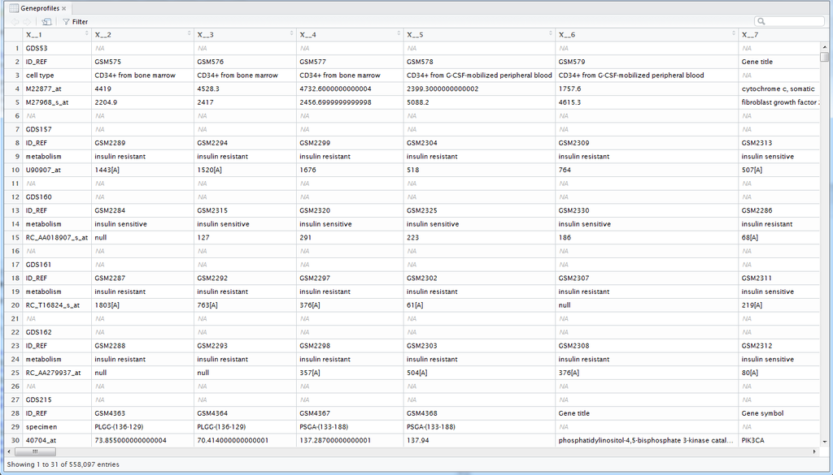

$~$  
$~$

# 3.Processing gene expression profiles

### 3.1.Creating a large list called listGeneprofiles which contains each part of Geneprofiles dataframe in one of its elements

The following codes are to create a large list called **listGeneprofiles**. each element of the list contains one row for the GDS name, one row for ID_REF, GSMs, Gene ids and Gene symbol, and multiple rows for the expression values.

An empty list called listGeneprofiles is created. To extract the information of each GDS part, rows indexes containing “GDS” are found. A “loop” is used to exert some operations on each GDS part. v1 is a vector which contains the row after GDS i (the row which start with ID_REF). “index” is a vector holding all the elements of v1 which start with GSM letters. “l” shows how many GSMs are present in row idx[i] + 1. “d” is a data frame as the same dimention as each GDS part. The number of rows in matrix d, is equal to The number of rows starting from GDS[i] to GDS[i+1] minus two (“length((idx[i]):(idx[i+1] - 2))”). The number of columns in object d, is equal to the sum of column one as well as all the GSM columns and two columns after GSM columns (length(c(1,index,index[l]+c(1,2))))). Whenever d is completed for GDS i, extra rows are deleted. In other words, row one and rows which contain expression values (have “at” or numbers at the end) are kept.

```r
listGeneprofiles = list()
idx = grep("^GDS" , Geneprofiles[,1])
for(i in 1:(length(idx)-1)){

  v1 =  data[idx[i]+1,]
  index = grep("^GSM" , v1)
  l = length(index)

  d = as.data.frame(matrix(0,length((idx[i]):(idx[i+1] - 2)) , length(c(1,index,index[l]+c(1,2)))))
  for(j in 1:length((idx[i]):(idx[i+1] - 2))) {
    d[j,] = Geneprofiles[idx[i]+j-1,c(1,index,index[l]+c(2,3))]
  }

  colnames(d) = d[2,]
  idxx = grep(paste(paste(c(0:9,'_at'),"$",sep=""),collapse="|"),d[,1])
  listGeneprofiles[[i]] = d[idxx,]

  #print(i)
}
```

```r
length(listGeneprofiles)
```

```
## [1] 73460
```

$~$

listGeneprofiles contains 73460 elements. each element has a similar structure as below.

```r
listGeneprofiles[[1]]
```

```
##        ID_REF GSM575 GSM576             GSM577             GSM578 GSM579
## 1       GDS53   <NA>   <NA>               <NA>               <NA>   <NA>
## 4   M22877_at   4419 4528.3 4732.6000000000004 2399.3000000000002 1757.6
## 5 M27968_s_at 2204.9   2417 2456.6999999999998             5088.2 4615.3
##   Gene symbol Gene ID
## 1        <NA>    <NA>
## 4        CYCS   54205
## 5        FGF2    2247
```

```r
listGeneprofiles[[57777]]
```

```
##        ID_REF          GSM136055          GSM136056          GSM136057
## 1     GDS2494               <NA>               <NA>               <NA>
## 5 200065_s_at            3630.35             3685.9            3662.81
## 6 202512_s_at 48.658799999999999 49.640799999999999              50.71
## 7 221497_x_at 162.16499999999999            128.107 138.99700000000001
##            GSM136064          GSM136065          GSM136066          GSM136058
## 1               <NA>               <NA>               <NA>               <NA>
## 5            3622.76            3423.19            3399.93            3083.94
## 6 72.458799999999997 55.823999999999998 71.829800000000006 38.535200000000003
## 7 90.802700000000002 82.813800000000001 78.484999999999999 142.18299999999999
##            GSM136059          GSM136060    Gene symbol         Gene ID
## 1               <NA>               <NA>           <NA>            <NA>
## 5            3125.62            3177.01 MIR3620///ARF1 100500810///375
## 6 38.714700000000001 43.994900000000001           ATG5            9474
## 7            156.648 143.34800000000001          EGLN1           54583
```

$~$  
$~$

### 3.2.Creating a list called preListGDS which contains each GDS (dataset) in one of its elements

The following codes show how many GDSes (datasets) does exist in the “listGeneprofiles” object.

```r
gds = c()
for(i in 1:length(listGeneprofiles)){
  gds[i] = listGeneprofiles[[i]][1,1]
}
gds1 = unique(gds)
```

```r
length(gds)
```

```
## [1] 73460
```

$~$

Same datasets are merged as below.

```r
preListGDS = list()
for(i in 1:length(gds)){
  idx = which(gds1[i]==gds)
  preListGDS[[i]] = do.call("rbind",listGeneprofiles[idx])
}
length(preListGDS)
```

```
## [1] 1693
```

```r
# There are 1693 datasets
```

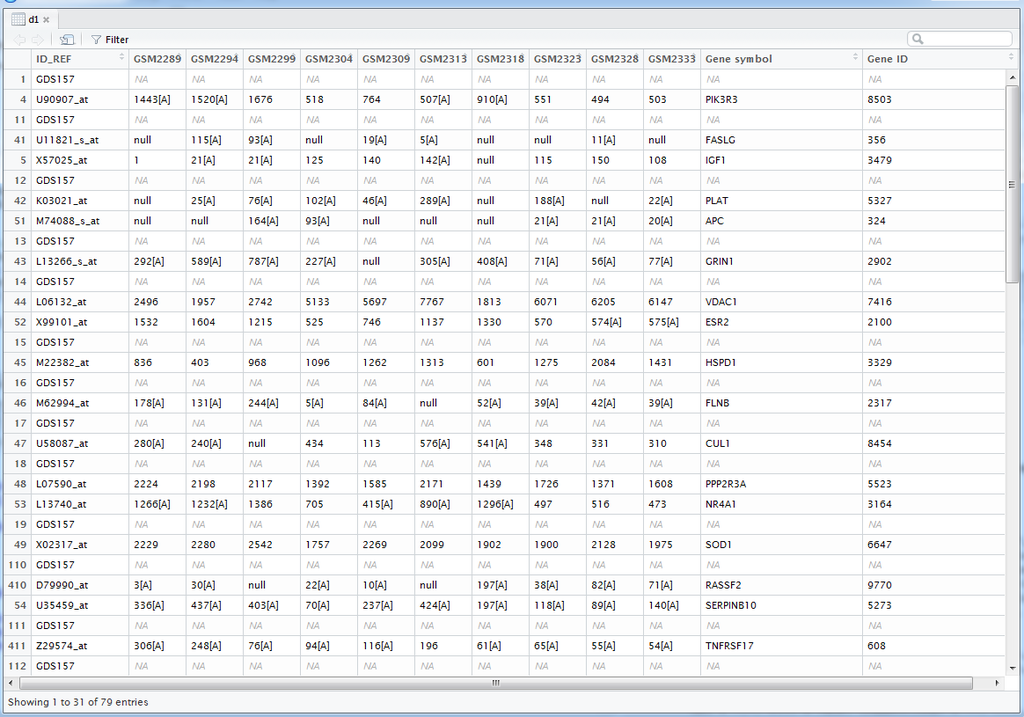

Figure5

$~$

$~$

Some datasets does not contain gene symbols or gene ids. We delete them as below.

```r
v = c()
for(i in 1:length(preListGDS)){
  v[i]="Gene symbol" %in% colnames(preListGDS[[i]]) & "Gene ID" %in% colnames(preListGDS[[i]])
}

index = which(!v)
index
```

```
## [1]  933 1062 1229 1332
```

```r
l = preListGDS[index]

c(l[[1]][1,1],l[[2]][1,1],l[[3]][1,1],l[[4]][1,1])
```

```
## [1] "GDS2771" "GDS3795" "GDS3268" "GDS4206"
```

```r
colnames(l[[2]])
```

```
##   [1] "ID_REF"    "GSM483301" "GSM483302" "GSM483303" "GSM483305" "GSM483307"
##   [7] "GSM483312" "GSM483313" "GSM483317" "GSM483318" "GSM483319" "GSM483322"
##  [13] "GSM483327" "GSM483328" "GSM483330" "GSM483332" "GSM483333" "GSM483336"
##  [19] "GSM483337" "GSM483339" "GSM483351" "GSM483352" "GSM483354" "GSM483358"
##  [25] "GSM483384" "GSM483386" "GSM483388" "GSM483390" "GSM483391" "GSM483396"
##  [31] "GSM483399" "GSM483400" "GSM483401" "GSM483412" "GSM483418" "GSM483420"
##  [37] "GSM483421" "GSM483426" "GSM483428" "GSM483431" "GSM483436" "GSM483442"
##  [43] "GSM483443" "GSM483444" "GSM483447" "GSM483448" "GSM483450" "GSM483455"
##  [49] "GSM483458" "GSM483461" "GSM483462" "GSM483464" "GSM483466" "GSM483468"
##  [55] "GSM483476" "GSM483477" "GSM483300" "GSM483308" "GSM483310" "GSM483311"
##  [61] "GSM483323" "GSM483338" "GSM483353" "GSM483361" "GSM483363" "GSM483364"
##  [67] "GSM483366" "GSM483368" "GSM483371" "GSM483372" "GSM483373" "GSM483374"
##  [73] "GSM483379" "GSM483380" "GSM483381" "GSM483389" "GSM483404" "GSM483405"
##  [79] "GSM483410" "GSM483411" "GSM483413" "GSM483416" "GSM483417" "GSM483419"
##  [85] "GSM483427" "GSM483433" "GSM483434" "GSM483445" "GSM483459" "GSM483465"
```

[output cut: 18 more lines]

$~$

```r
preListGDS = preListGDS[-index]
length(preListGDS)
```

```
## [1] 1689
```

$~$

GDS rows are deleted from each element of preListGDS as below.

```r
for(i in 1:length(preListGDS)){
  preListGDS[[i]] = preListGDS[[i]][!grepl("^GDS",preListGDS[[i]][,1]),-1]
}
```

$~$

### 3.3.Editing preListGDS object into ListGDS

Datasets in **preListGDS** are required to be edited; so, a “for loop” along with 4 conditions are created to edit preListGDS. edited preListGDS is called **ListGDS**. In the gene symbol column of most of GDSes, there are multiple gene symbols for one value. In that case, the gene symbol which is in the edgelist is selected.

```r
ListGDS = preListGDS
```

```r
# The first condition determines if there is a need for editing

# The second condition is for when there are multiple gene symbols for one value and
# more than one of them is mapped to the edgelist genes.

# Thr third condition is for when there are multiple gene symbols for one value,
# but none of them mapped to the gene set "Gene"

# The forth condition is for when there are multiple gene symbols for one value and
# only one of them is mapped to the gene set "Gene""


for(i in 1:length(ListGDS)){

  l1 = length(ListGDS[[i]][1,]) - 1

  a = ListGDS[[i]][,l1]

  a = strsplit(a,"///",fixed = T)

  l = unlist(lapply(a,length))

  idxx = which(l>1)

    if(length(idxx>0)){
    a1 = a[idxx]
    for(j in 1:length(a1)){
      idxx1 = which(a1[[j]] %in% edgelistGenes)
      if(length(idxx1>1)){
        ListGDS[[i]][,l1][idxx[j]] = a[idxx][[j]][idxx1[1]]
      } else if(length(idxx1)==0){
        ListGDS[[i]][,l1][idxx[j]] = a[idxx][[j]][1]
      } else {
        ListGDS[[i]][,l1][idxx[j]] = a[idxx][[j]][idxx1]
      }
    }
  }

  # Deleting regular [A] characters next to the some values
  # changing class of values to numeric
  # changing order of columns

  ListGDS[[i]] = cbind(ListGDS[[i]][,l1,drop=F],ListGDS[[i]][,1:(l1-1),drop=F])
  ListGDS[[i]] = as.data.frame(ListGDS[[i]],stringsAsFactors=F)

  for(j in 2:l1){
    ListGDS[[i]][,j] = sub("\\[A]","",ListGDS[[i]][,j])
    ListGDS[[i]][,j] = as.numeric(ListGDS[[i]][,j])
  }

   #print(i)
}
```

```r
head(ListGDS[[1]] , 20)
```

```
##     Gene symbol  GSM575  GSM576  GSM577  GSM578  GSM579
## 4          CYCS  4419.0  4528.3  4732.6  2399.3  1757.6
## 5          FGF2  2204.9  2417.0  2456.7  5088.2  4615.3
## 41         GAS6   765.9   562.4   667.5   364.8   395.6
## 51         GRB2   226.2   212.6   198.2    10.3    34.3
## 42        IL2RB   367.8   508.4   328.2    57.9    34.3
## 52           F3   573.5   607.5   356.9    79.9    21.6
## 6        CASP10  1765.1  1400.3  1843.8   660.6   479.1
## 7         PTPRM   676.4   622.7   611.0   309.4   298.9
## 43       IQGAP1   508.0   482.1   480.6   323.9   328.9
## 44       SREBF1  8303.8  9411.2  8260.5  3804.7  4592.9
## 53         FGD1  2637.9  2035.4  1447.3  5435.8  4638.0
## 61          RHO  6781.8  6509.0  7001.6 10833.1 11141.8
## 45         THRA 21144.2 45869.4 52175.2  9517.2  6752.6
## 46       PLA2R1   721.7   375.6   462.5  5271.3  6598.9
## 47        RAB7A  4117.5  4042.4  2926.3 10662.4 11609.5
## 48         SDC2  1846.2  1794.0  2030.2   656.4   776.9
## 54           C5   167.4    41.9    33.5   326.9   295.8
## 49      PPP2R5A  6597.4  7377.2  8328.5  3951.5  3474.7
## 410        IRF9   445.3   315.8   283.7  2369.0  3024.7
## 411   SERPINB10   570.1   478.5   465.0   123.3   109.5
```

```r
head(preListGDS[[1]] , 20)
```

```
##                 GSM575             GSM576             GSM577             GSM578
## 4                 4419             4528.3 4732.6000000000004 2399.3000000000002
## 5               2204.9               2417 2456.6999999999998             5088.2
## 41               765.9              562.4              667.5              364.8
## 51            226.2[A]           212.6[A]           198.2[A]            10.3[A]
## 42               367.8              508.4              328.2               57.9
## 52               573.5              607.5              356.9            79.9[A]
## 6               1765.1             1400.3             1843.8           660.6[A]
## 7                676.4 622.70000000000005                611           309.4[A]
## 43              508[A]           482.1[A]           480.6[A]           323.9[A]
## 44  8303.7999999999993 9411.2000000000007             8260.5             3804.7
## 53              2637.9             2035.4             1447.3             5435.8
## 61              6781.8               6509             7001.6            10833.1
## 45             21144.2            45869.4 52175.199999999997 9517.2000000000007
## 46               721.7              375.6              462.5             5271.3
```

[output cut: 27 more lines]

```r
class(ListGDS[[1]][,4])
```

```
## [1] "numeric"
```

```r
# We keep gene symbols and delete columns related to gene Ids

dim(ListGDS[[1]])
```

```
## [1] 49  6
```

```r
dim(preListGDS[[1]])
```

```
## [1] 49  7
```

$~$

The following code, shows the indices in GDSes containing repetitious GSMs.

```r
indexx = list()
for(i in 1:length(ListGDS)){

  logic=c()

  for(j in (1:length(ListGDS))[-i]){
    logic[j]=any(colnames(ListGDS[[i]])[-1] %in% colnames(ListGDS[[j]]))
  }
  index = which(logic)
  if(length(index) > 0){
    indexx[i] = index
  }
  print(i)
}

index.of.GDSes.having.repetitious.GSMs = which(unlist(lapply(indexx , length)) > 0)
```

$~$

In the code below, repetitious GSMs are deleted in different GDSes.

```r
for(i in 1:length(ListGDS)){

  logic=c()
  for(j in (1:length(ListGDS))[-i]){
    logic[j]=any(colnames(ListGDS[[i]])[-1] %in% colnames(ListGDS[[j]]))
  }
  index = which(logic)
  if(length(index) > 0){
    for(z in 1:length(index)){
      logicc = colnames(ListGDS[[index[z]]]) %in% colnames(ListGDS[[i]])[-1]
      indexx = which(logicc)
      ListGDS[[index[z]]]=ListGDS[[index[z]]][,-indexx]
    }
  }
  # print(i)
}
```

$~$

Indices in ListGDS for which there is no GSM left are omitted.

```r
index = which(unlist(lapply(lapply(lapply(ListGDS , dim) , function(x) x[2]) , function(x) length(x) == 0)))
ListGDS = ListGDS[-index]
```

```r
# All the datasets have more than two GSMs
which(unlist(lapply(lapply(lapply(ListGDS , dim) , function(x) x[2]), function(x) x < 2)))
```

```
## integer(0)
```

$~$

Indices in ListGDS for which there is no gene left are removed.

```r
index = which(unlist(lapply(lapply(lapply(ListGDS , dim) , function(x) x[1]) , function(x) x < 2)))
ListGDS = ListGDS[-index]
```

$~$

All the gene names that are in the ListGDS object, are stored in an object called **profilesGenes**.

```r
profilesGenes = c()

for(i in 1:length(ListGDS)){
  profilesGenes = c(profilesGenes,ListGDS[[i]][,1])
}

profilesGenes = unique(profilesGenes)

any(is.na(profilesGenes))

profilesGenes = profilesGenes[-which(is.na(profilesGenes))]
```

```r
length(profilesGenes)
```

```
## [1] 3207
```

$~$

The first row in the KEGG edgelist contains “EGF” gene. Check how many datasets contain this gene.

```r
which(profilesGenes == "EGF")
```

```
## [1] 1679
```

```r
logic=c()
for(i in 1:length(ListGDS)){
  logic[i] =  profilesGenes[1679] %in% ListGDS[[i]][,1]
}
idxng1679 = which(logic)
length(which(logic))
```

```
## [1] 44
```

```r
head(ListGDS[[idxng1679[20]]],10)
```

```
##    Gene symbol GSM1200171 GSM1200172 GSM1200173 GSM1200174
## 4       PRKACB  3762.2700  3588.7100  5354.8300  5143.6300
## 5          FAS   204.5730   195.6560   507.2090   473.8230
## 6          FAS   178.3230   169.3150   401.8230   366.3830
## 7          EGF    72.6697    66.5497    22.1397    22.2993
## 8         CYCS  8361.6400  8924.8400  5821.4400  6205.0000
## 9          HGF    36.7687    40.6940    85.0087    88.0442
## 10         HGF    51.4297    47.0476    83.9657    83.3615
## 11         FAS   107.4120   103.9990   317.9370   290.5730
## 12         FAS    60.8529    55.7002   161.3550   140.7340
## 13        CYCS    40.3911    42.7323    20.5259    17.2582
```

```r
length(profilesGenes) # 3207 is the number of genes extracted from all the gene profiles
```

```
## [1] 3207
```

```r
length(edgelistGenes) # 3187 is the number of genes at the edgelist
```

```
## [1] 3187
```

$~$

common genes between gene profiles and edgelist are stored in **Genes** object.

```r
sum(profilesGenes %in% edgelistGenes)

Genes = profilesGenes[which(profilesGenes %in% edgelistGenes)]
```

```r
length(Genes)
```

```
## [1] 3047
```

```r
# There are 3047 common genes between the gene profiles and the edgelist
```

$~$

In the folowing code all the GSM names are stored at **gsms** object.

```r
list3=list()
for(i in 1:(length(ListGDS))){
  index = grep("^GSM" , colnames(ListGDS[[i]]))
  list3[[i]] = colnames(ListGDS[[i]])[index]
}
length(list3)

gsm = unlist(list3)

gsms = unique(gsm)
```

```r
length(gsms)
```

```
## [1] 40903
```

$~$  
$~$

### 3.4.Constructing an expression matrix called Exprtable which contains all the gene values amongst the GSMs

First of all, an NA matrix called **Exprtable** is created which has genes in row and GSMs in column. for each gene name, a sublist is created by a loop. For gene one, we check which GDSes of ListGDS object contain it. Then, we store these GDSes at a **sublist** object. After that, for each element in the sublist, the rows indicating the gene i are stored at **idxx** object. If there is just one row, we put that row in Exprtable object. Otherwise, the row with larger IQR is located in Exprtable expression matrix.

```r
Exprtable = matrix(NA,length(Genes),length(gsms))

Exprtable = as.data.frame(Exprtable)

rownames(Exprtable) = Genes

colnames(Exprtable) = gsms
```

```r
dim(Exprtable)
```

```
## [1]  3047 40903
```

```r
for(i in 1:length(Genes)){


  logic = c()
  for(j in 1:length(ListGDS)){
    logic[j] = Genes[i] %in% ListGDS[[j]][,1]
  }
  sublist = ListGDS[logic]


  for(j in 1:length(sublist)){

    gsm = colnames(sublist[[j]])[-1]

      idxx = which(sublist[[j]][,1] == Genes[i])

      if(length(idxx) == 1){
        Exprtable[Genes[i],gsm] = sublist[[j]][idxx,-1]
      } else {
            d = sublist[[j]][idxx,-1]
            IQRs = c()
           for(z in 1:length(d[,1])){
            a=as.numeric(na.omit(as.numeric(d[z,])))
            IQRs[z] = quantile(a, 0.75 ) - quantile(a, 0.25)
            Exprtable[Genes[i],gsm] = d[which.max(IQRs),]
          }

        }
      }
      #print(i)
    }
```

```r
sum(is.na(Exprtable))
```

```
## [1] 120876590
```

```r
sum(!(is.na(Exprtable)))
```

```
## [1] 3754851
```

$~$  
$~$

### 3.5.designing a list called preSignalingNet1 which contains expression values for each edge

```r
preSignalingNet1 = list()
for(i in 1:length(edgelist[,1])){
  gene1 = edgelist[,2:3][i,1]
  gene2 = edgelist[,2:3][i,2]

  idx1 = which(gene1 == rownames(Exprtable))
  idx2 = which(gene2 == rownames(Exprtable))
  a = Exprtable[idx1,]
  b = Exprtable[idx2,]
  l1 = !is.na(a)
  l2 = !is.na(b)

  if(length(intersect(which(l1),which(l2))) > 0){
    d = rbind(a,b)
    idx = intersect(which(l1),which(l2))
    preSignalingNet1[[i]] = d[,idx]
    names(preSignalingNet1)[i] = edgelist[i,1]
  } else {
    preSignalingNet1[[i]] = "empty"
    names(preSignalingNet1)[i] = edgelist[i,1]
  }
  #print(i)
}
```

$~$

The information for the edge 10000 is diepicted as follow. THBS4 is the source gene and CD47 is the target gene.

```r
edgelist[10000,]
```

```
##           ID Gene1 Gene2 Interaction type
## 10000 E10000 THBS4  CD47       activation
```

```r
preSignalingNet1[[10000]]
```

```
##       GSM183695 GSM185526 GSM185527 GSM185528 GSM185529 GSM185530 GSM185531
## THBS4   86.5063   80.9516  13.80250   285.017  310.7550   39.8476   521.398
## CD47    20.8250   33.1526   3.27527    11.985   32.0414   24.6110     3.422
##       GSM185532 GSM185533 GSM185534 GSM185535 GSM185536 GSM47867 GSM47868
## THBS4 254.00900 686.64900 525.22700  404.1640 733.72700     33.9     36.0
## CD47    7.69714   4.67268   7.08067   29.6316   9.12542     90.9     26.7
##       GSM47700 GSM47862 GSM47869 GSM47863 GSM47864 GSM47870 GSM47871 GSM47865
## THBS4     23.2     31.1     22.2      6.3      6.1     91.4     58.3     61.7
## CD47      38.5     50.4     74.3     75.0     44.1      4.8     22.8      4.3
##       GSM47866 GSM112271 GSM112272 GSM112273 GSM112274 GSM112275 GSM112276
## THBS4     56.3   -0.7179   -0.1888   -0.7167   -0.6063   -0.9728   -0.8966
## CD47       1.7    0.4725    0.3915    0.0521    0.1217   -0.5224   -0.4888
##       GSM112277 GSM112278 GSM112279 GSM112280 GSM112281 GSM112282 GSM112283
## THBS4   -1.1997   -2.0078   -0.9423   -0.6307   -1.0251   -1.0449   -1.2765
## CD47    -0.8899   -0.9997    0.0867    0.1363   -0.5541   -0.5307   -1.0612
##       GSM112284 GSM112285 GSM112286 GSM112287 GSM112288 GSM112289 GSM112290
## THBS4   -1.3115    0.4004    0.2038    0.1565    0.3431   -0.5992   -0.6471
## CD47    -1.1395    0.6933    0.6035    0.2097    0.2109    0.0369    0.0715
##       GSM112293 GSM112294 GSM112295 GSM112296 GSM112297 GSM112298
## THBS4    0.1637    0.1986   -0.8115   -0.6926   -0.8596   -0.8864
## CD47     0.4232    0.4921   -0.0582   -0.2459   -0.5638   -0.7999
```

$~$

```r
idx.NO.gsms = which(preSignalingNet1 %in% "empty" )
```

```r
length(idx.NO.gsms)
```

```
## [1] 10650
```

$~$

### 3.7.Creating preSignalingNet2

All the values in each preSignalingNet1 element are separated based on the source of datasets and they are stored at **preSignalingNet2** object. Furthermore, for some indices of preSignalingNet1, source and target genes are the same and they have exactly the same values. These indices are stored at **index.of.not.matching.preSignalingNet.and.ListGDS** object and they are assigned empty in preSignalingNet2 object. **‘These indices are related to loops in the edgelist.’**

```r
preSignalingNet2 = preSignalingNet1

index.of.not.matching.preSignalingNet.and.ListGDS=c()

for(i in (1:length(preSignalingNet1))[-idx.NO.gsms]){


  # Here the index object get indices of all the GDSes which have created signalingnet[[i]] and have the source and target genes
  logic=c()
  for(j in 1:length(ListGDS)){
    logic[j]=any(colnames(preSignalingNet1[[i]]) %in% colnames(ListGDS[[j]])) & all(rownames(preSignalingNet1[[i]]) %in% ListGDS[[j]][,1])
  }
  index = which(logic)

  if(length(index) > 1){
    coexpr = ListGDS[index]
    coEXpr = list()
    colNAMES = lapply(coexpr,colnames)
    for(z in 1:length(coexpr)){
      coEXpr[[z]]=preSignalingNet1[[i]][ , colNAMES[[z]][which( colNAMES[[z]] %in% colnames(preSignalingNet1[[i]]))]]

    }
    preSignalingNet2[[i]] = coEXpr

  } else if(length(index) == 1){
    preSignalingNet2[[i]] = preSignalingNet1[[i]]

  } else {
    preSignalingNet2[[i]] = "empty"
    index.of.not.matching.preSignalingNet.and.ListGDS[i] = i
  }

}

index.of.not.matching.preSignalingNet.and.ListGDS = which(!is.na(unlist(index.of.not.matching.preSignalingNet.and.ListGDS)))
```

$~$

```r
index.of.not.matching.preSignalingNet.and.ListGDS
```

```
##  [1]   213  5245  5258  5271  5284  5297  5310  5323  5336  5349  5362  5375
## [13]  5388  8711  8715  8719 10057 10060 10077 10080 10081 10082 10083 10084
## [25] 10134 16235 17298 18206 18445 18447 18574 21348 21352 21356 25757
```

```r
edgelist[index.of.not.matching.preSignalingNet.and.ListGDS[1:4],]
```

```
##          ID   Gene1   Gene2 Interaction type
## 213  E00213   HBEGF   HBEGF       activation
## 5245 E05245 ANAPC10 ANAPC10       activation
## 5258 E05258   CDC26   CDC26       activation
## 5271 E05271 ANAPC13 ANAPC13       activation
```

```r
preSignalingNet1[[index.of.not.matching.preSignalingNet.and.ListGDS[2]]][,1:6]
```

```
##          GSM1305903 GSM1305905 GSM1305907 GSM1305909 GSM1305902 GSM1305904
## ANAPC10       49.98      52.17      56.98      54.39      33.34      27.26
## ANAPC101      49.98      52.17      56.98      54.39      33.34      27.26
```

$~$

```r
Eligibles =  (1:length(preSignalingNet2))[-c(index.of.not.matching.preSignalingNet.and.ListGDS,idx.NO.gsms)]
length(Eligibles)
# There are 15805 edges for down stream analysis
```

$~$

Correlation analysis was performed on each edge (gene pair) after preprocessing step. Samples having value for the gene pairs, may come from different datasets and they should be separated and analyzed independently. Figure 6 represents the effect of this preprocessing on a gene pairs in the dataset. In panel A, because all the values are related to multiple datasets in preSignalingNet1[[4]], we can see a highly data dispersion. However, in the preSignalingNe2[[4]] all of these values are separated into 14 datasets. in panel B, six of these separated datasets are plotted.

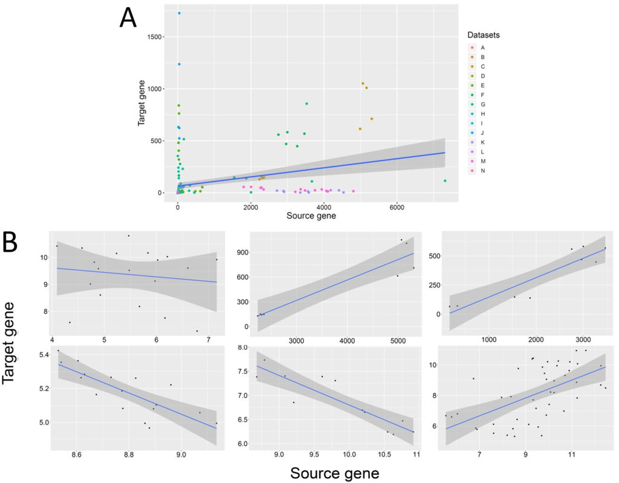

Figure 6

$~$

$~$

$~$  
$~$

#### Getting rid of outliers

Values 1.5 times more than IQR are considered as outliers and are taken out.

```r
for(i in Eligibles){

  if(class(preSignalingNet2[[i]])=="list"){
for(j in 1:length(preSignalingNet2[[i]]))
  outliers1 = boxplot.stats(as.numeric(preSignalingNet2[[i]][[j]][1,]))$out
  outliers2 = boxplot.stats(as.numeric(preSignalingNet2[[i]][[j]][2,]))$out

  index1 = which(as.numeric(preSignalingNet2[[i]][[j]][2,]) %in% outliers1)
  index2 = which(as.numeric(preSignalingNet2[[i]][[j]][2,]) %in% outliers2)
  index = unique(c(index1,index2))
  if(length(index) > 0){
  preSignalingNet2[[i]][[j]] = preSignalingNet2[[i]][[j]][,-index]
  }

  } else {
  outliers1 = boxplot.stats(as.numeric(preSignalingNet2[[i]][1,]))$out
  outliers2 = boxplot.stats(as.numeric(preSignalingNet2[[i]][2,]))$out

  index1 = which(as.numeric(preSignalingNet2[[i]][1,]) %in% outliers1)
  index2 = which(as.numeric(preSignalingNet2[[i]][2,]) %in% outliers2)
  index = unique(c(index1,index2))
  if(length(index) > 0){
    preSignalingNet2[[i]] = preSignalingNet2[[i]][,-index]}

  }
}
```

$~$

```r
CLASS = lapply(preSignalingNet2 , class)
all(lapply(lapply(preSignalingNet2[which(CLASS == "data.frame")] , dim), function(x) x[2]) > 2)
```

```
## [1] FALSE
```

$~$

The following code presents the number of datasets which have two or fewer datasets.

```r
sum(unlist(lapply(preSignalingNet2[which(CLASS == "list")] , function(x) lapply(x,function(x) dim(x)[2] <= 2))))
```

```
## [1] 43
```

$~$

The following code shows the indices in preSignalingNet2 in the class list having datasets with less than three samples.

```r
index = which(unlist(lapply(preSignalingNet2[which(CLASS == "list")] , function(x) any(unlist(lapply(x,function(x) dim(x)[2] < 3))))))
index
```

```
## E00598 E00868 E00877 E01073 E01081 E01430 E01439 E04464 E04490 E06633 E06640
##    393    550    556    683    689    914    921   2509   2527   3398   3405
## E06648 E06655 E06657 E06665 E06672 E06858 E06865 E06873 E06880 E06882 E06890
##   3413   3420   3422   3430   3436   3569   3576   3583   3589   3590   3596
## E06897 E07488 E07495 E07503 E07510 E07512 E07520 E07527 E09571 E09777 E09842
##   3602   4081   4087   4091   4096   4098   4103   4109   4999   5144   5193
## E13198 E16423 E16428 E17413 E17743 E18042 E18711 E25851 E25910 E25914
##   6901   7581   7586   8053   8216   8389   8787  11007  11050  11054
```

$~$

```r
preSignalingNet2[which(CLASS == "list")][[index[1]]]
```

```
## [[1]]
##        GSM4312 GSM4317
## TGFB3  296.045 109.721
## TGFBR2  24.545 136.243
##
## [[2]]
##         GSM7621  GSM7622 GSM7623 GSM7624  GSM6681  GSM6682 GSM6683 GSM6684
## TGFB3   848.063  827.429 3403.71 2631.38  739.542  606.972 3023.23 2892.95
## TGFBR2 5545.760 5872.560 8368.38 7563.18 5431.500 5991.290 7298.31 6956.94
##         GSM6685  GSM6686 GSM6687 GSM6688
## TGFB3   715.008  824.526 3184.55 2850.80
## TGFBR2 4540.660 4318.670 7407.48 6698.04
```

$~$

Ineligible datasets are omitted from the preSignalingNet2 through the following code. Ineligible datasets are those which contain less than three samples.

```r
for(i in 1:length(index)){
  idx = which(unlist(lapply(lapply(preSignalingNet2[which(CLASS == "list")][index][[i]] , dim) , function(x) x[2]<= 2)))
  preSignalingNet2[which(CLASS == "list")][index][[i]] = preSignalingNet2[which(CLASS == "list")][index][[i]][-idx]
}
```

$~$

the following code is to check whether there is any element of preSignalingNet2 in class list with the length of one.

```r
index = which(lapply(preSignalingNet2 , class) == "list" & lapply(preSignalingNet2 , length) == 1)
index
```

```
## E00598
##    598
```

```r
preSignalingNet2[[index]] = as.data.frame(preSignalingNet2[[index]])
```

$~$

Because some changes may be imposed on some elements, another checking is done to make sure all the datasets have more than two GSMs.

```r
CLASS = lapply(preSignalingNet2 , class)
all(lapply(lapply(preSignalingNet2[which(CLASS == "data.frame")] , dim), function(x) x[2]) > 2)
```

```
## [1] FALSE
```

```r
all(unlist(lapply(preSignalingNet2[which(CLASS == "list")] , function(x) any(unlist(lapply(x,function(x) dim(x)[2] >= 3))))))
```

```
## [1] TRUE
```

$~$

The elements which contain less than three GSMs are assigned empty.

```r
index = which(lapply(lapply(preSignalingNet2[which(CLASS == "data.frame")] , dim), function(x) x[2]) < 3)
index
```

```
## E12586
##   2460
```

```r
if(length(index)>0){
preSignalingNet2[which(CLASS == "data.frame")][[index]]
preSignalingNet2[which(CLASS == "data.frame")][[index]] = "empty"
}
```

$~$

Eligible edges are updated.

```r
Eligibles =  which(lapply(preSignalingNet2 , class) == "list" | lapply(preSignalingNet2 , class) == "data.frame")
length(Eligibles)
```

```
## [1] 15804
```

$~$

# 4.Correlation analysis for each edge

### 4.1.Creating a large list called SignalingNet which contains expression values and correlation information for each edge

The next step is to compute the correlation between the two interacting genes. Pearson, Spearman and Kendall correlation tests are calculated for each edge and a list called **SignalingNet** is created.

```r
SignalingNet = preSignalingNet2

for(i in Eligibles){

  if(class(SignalingNet[[i]])=="list"){
  corAnalysis = list()
  dim = list()
  for(j in 1:length(SignalingNet[[i]])){

  p = cor.test(as.numeric(SignalingNet[[i]][[j]][1,]) , as.numeric(SignalingNet[[i]][[j]][2,]) , method = "pearson")
  s = cor.test(as.numeric(SignalingNet[[i]][[j]][1,]) , as.numeric(SignalingNet[[i]][[j]][2,]) , method = "spearman")
  k = cor.test(as.numeric(SignalingNet[[i]][[j]][1,]) , as.numeric(SignalingNet[[i]][[j]][2,]) , method = "kendall")
  pearson = as.data.frame(cbind(pearsoncor = unname(p$estimate) , pearsonpval = p$p.value))
  spearman = as.data.frame(cbind(spearmancor = unname(s$estimate) , spearmanpval = s$p.value))
  kendall = as.data.frame(cbind(kendallcor = unname(k$estimate) , kendallpval = k$p.value))
  corAnalysis[[j]] = list(pearson = pearson,spearman = spearman,kendall = kendall)
  dim[[j]] = dim(SignalingNet[[i]][[j]])
  }

  SignalingNet[[i]] = list(Source = unname(edgelist[i,2]) , Target = unname(edgelist[i,3])  , length = length(SignalingNet[[i]]) ,dim = dim , coExpr =  SignalingNet[[i]] ,
                             corAnalysis = corAnalysis , Interactiontype = unname(edgelist[i,4]) , Coherency = "empty")

  } else {
    p = cor.test(as.numeric(SignalingNet[[i]][1,]) , as.numeric(SignalingNet[[i]][2,]) , method = "pearson")
    s = cor.test(as.numeric(SignalingNet[[i]][1,]) , as.numeric(SignalingNet[[i]][2,]) , method = "spearman")
    k = cor.test(as.numeric(SignalingNet[[i]][1,]) , as.numeric(SignalingNet[[i]][2,]) , method = "kendall")
    pearson = as.data.frame(cbind(pearsoncor = unname(p$estimate) , pearsonpval = p$p.value))
    spearman = as.data.frame(cbind(spearmancor = unname(s$estimate) , spearmanpval = s$p.value))
    kendall = as.data.frame(cbind(kendallcor = unname(k$estimate) , kendallpval = k$p.value))


    SignalingNet[[i]] = list(Source = unname(edgelist[i,2]) , Target = unname(edgelist[i,3]) , length = 1 ,dim = dim(SignalingNet[[i]]) , coExpr =  SignalingNet[[i]] ,
                               corAnalysis = list(pearson = pearson,spearman = spearman,kendall = kendall) ,
                               Interactiontype = unname(edgelist[i,4]) , Coherency = "empty")
  }

}



for(i in (1:length(SignalingNet))[-Eligibles]){
  SignalingNet[[i]] = list(Source = unname(edgelist[i,2]) , Target = unname(edgelist[i,3]) , length = 0 ,dim = 0 , coExpr = NA , corAnalysis = NA , Interactiontype = unname(edgelist[i,4]) , Coherency = "empty")
}
```

$~$

#### An example of eligible edge:

```r
SignalingNet[[70]]
```

```
## $Source
## [1] "PDGFRB"
##
## $Target
## [1] "PLCG2"
##
## $length
## [1] 4
##
## $dim
## $dim[[1]]
## [1] 2 8
##
## $dim[[2]]
## [1] 2 8
##
## $dim[[3]]
## [1]  2 10
##
## $dim[[4]]
## [1]  2 30
##
##
## $coExpr
## $coExpr[[1]]
##        GSM490979 GSM490980 GSM490981 GSM490982 GSM490983 GSM490984 GSM490985
## PDGFRB   8.13064   8.35757   7.80769   8.03344   9.01956   8.54397   9.12372
## PLCG2    6.11117   6.29475   6.50859   6.23847   5.81704   5.82973   5.92684
##        GSM490986
## PDGFRB   9.15383
## PLCG2    6.08239
##
## $coExpr[[2]]
##        GSM244647 GSM244649 GSM244651 GSM244653 GSM244648 GSM244650 GSM244652
## PDGFRB   36.1238   39.6828   6.70644   13.8024   21.5159   34.3139   11.9610
## PLCG2   360.3680  373.0510  85.62970   68.4027  428.7340  424.1310   59.5258
##        GSM244654
## PDGFRB   12.7781
## PLCG2   104.2860
##
```

[output cut: 74 more lines]

```
## $corAnalysis[[4]]$spearman
##   spearmancor spearmanpval
## 1   0.1764182    0.3495161
##
## $corAnalysis[[4]]$kendall
##   kendallcor kendallpval
## 1  0.1310345   0.3206742
##
##
##
## $Interactiontype
## [1] "activation"
##
## $Coherency
## [1] "empty"
```